# Esercizio da Svolgere di Inferenza Statistica

Gabriele Granzotto

08-07-2024

L’esercizio assegnato deve essere svolto per mezzo del software statistico R. Il codice e i risultati devono essere riportati in un documento, insieme al testo di commento ed eventuali grafici.

# Esercizio

Sia $(X_1, X_2, ... , X_n)$ un campione casuale generato da $X ∼ N (0, 1)$ e sia $T_n = \Sigma^n_{i=1} X^2_i$.

1. Fissando $n$, si studi la distribuzione di $T_n$ utilizzando un approccio di tipo Monte Carlo, evidenziando il confronto con la densità teorica della v.a. $T_n$.
2. Con riferimento al punto precedente, confrontare i momenti caratteristici calcolati sulla distribuzione empirica ottenuta via simulazione con gli analoghi indicatori della distribuzione teorica (media, varianza, curtosi, percentili, ecc.) all’aumentare del numero di repliche $M$ , con $500 ≤ M ≤ 5000$ e commentare i risultati.
3. Supponendo ora di generare campioni di ampiezza crescente, si cerchi di stabilire via simulazione la bontà dell’approssimazione fornita dalla distribuzione normale alla distribuzione di $T_n$.

# Svolgimento

### 1.

Come prima cosa carico le librerie:

- “ggplot” per disegnare i grafici;
- “moments” per calcolare i momenti della funzione empirica;
- “tibble” per fare i Dataset.

```r
library(ggplot2)
library(moments)
library(tibble)
```

Successivamente si inseriscono i parametri:

- $n$, numero di normali standard da sommare;
- $M$, numero di ripetizioni con il metodo di Montecarlo.

E si calcolano le distribuzioni attraverso un ciclo.

```r
numero.valori.generati.normale <- 5
numero.ripetizioni.montecarlo <- 5000

distribuzione.T <- array(dim = numero.ripetizioni.montecarlo)
for (i in 1:numero.ripetizioni.montecarlo)
{
  valori.normale <- rnorm(numero.valori.generati.normale);
  distribuzione.T[i] <- sum(valori.normale**2)
}
```

Infine si “plottano” la distribuzione teorica (in rosso) e quella empirica (in blu).

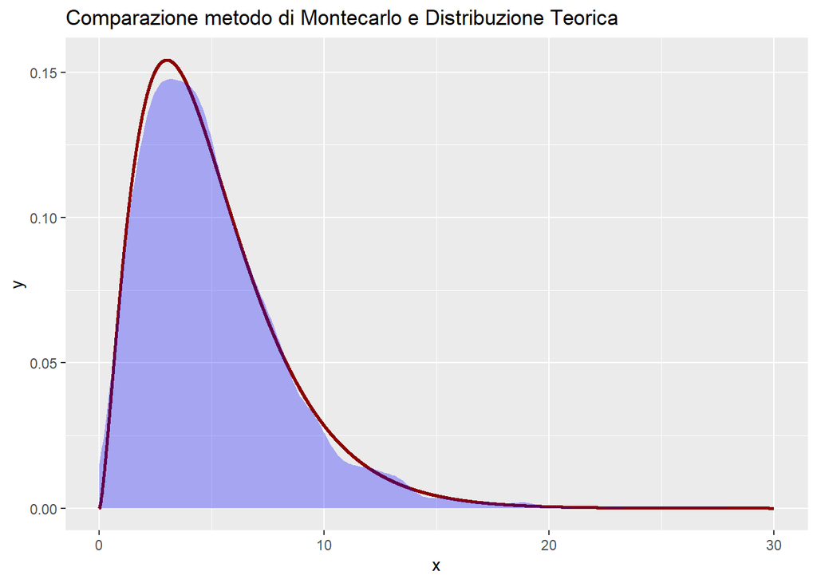

```r
ggplot(data=dati.teorici) +
  geom_line(aes(x=x, y=Chi), color="darkred", linewidth=1) +
  geom_density(aes(x=distribuzione.T), color="transparent", fill="blue", alpha=0.3) +
  xlim(0, 30) +
  labs(title = "Comparazione metodo di Montecarlo e Distribuzione Teorica", y="y", x="x")
```

### 2.

Ora si calcolano media, varianza, skewness e curtosi teoriche di una $\chi^2_{n}$.

- media: $n$;
- varianza: $2n$;
- skewness: $\sqrt{\frac{8}{n}}$;
- curtosi: $\frac{12}{n}$.

```r
media <- numero.valori.generati.normale
varianza <- 2*numero.valori.generati.normale
skewness <- sqrt(8/numero.valori.generati.normale)
curtosi <- 12/numero.valori.generati.normale
```

E si calcolano anche i momenti (dal primo al quarto) per calcolare rispettivamente media, varianza, skewness e curtosi empiriche.

- media: $E[X] = m_1$;
- varianza: $V[X] = m_2 - m_1^2$;
- skewness: $\beta_1 = \frac{m_3}{m_2^{3/2}}$;
- curtosi: $\beta_2 = \frac{m_4}{m_2^2}$.

```r
m1 <- moment(distribuzione.T, order = 1, central = TRUE)
m2 <- moment(distribuzione.T, order = 2, central = TRUE)
m3 <- moment(distribuzione.T, order = 3, central = TRUE)
m4 <- moment(distribuzione.T, order = 4, central = TRUE)

media_montecarlo <- moment(distribuzione.T, order = 1, central = FALSE)
varianza_montecarlo <- m2 - m1^2
skewness_montecarlo <- m3/sqrt(m2^3)
curtosi_montecarlo <- m4/(m2)^2
```

Infine si stampano i risultati.

```r
print(paste("Media Teorica: ", media))
```

```
## [1] "Media Teorica:  5"
```

```r
print(paste("Media Empirica:", round(media_montecarlo, 4)))
```

```
## [1] "Media Empirica: 4.975"
```

```r
print(paste("Varianza Teorica: ", varianza))
```

```
## [1] "Varianza Teorica:  10"
```

```r
print(paste("Varianza Empirica:", round(varianza_montecarlo,4)))
```

```
## [1] "Varianza Empirica: 10.0699"
```

```r
print(paste("Skewness Teorica: ", round(skewness,4)))
```

```
## [1] "Skewness Teorica:  1.2649"
```

```r
print(paste("Skewness Empirica:", round(skewness_montecarlo,4)))
```

```
## [1] "Skewness Empirica: 1.3452"
```

```r
print(paste("Curtosi Teorica: ", curtosi))
```

```
## [1] "Curtosi Teorica:  2.4"
```

```r
print(paste("Curtosi Empirica:", round(curtosi_montecarlo,4)))
```

```
## [1] "Curtosi Empirica: 5.8766"
```

Adesso si ripete il processo per valori di $M$ tra $500$ e $5000$.

```r
numero.valori.generati.normale <- 10

media <- numero.valori.generati.normale
varianza <- 2*numero.valori.generati.normale
skewness <- sqrt(8/numero.valori.generati.normale)
curtosi <- 12/numero.valori.generati.normale

n <- vector()
m <- vector()
v <- vector()
s <- vector()
c <- vector()

for (numero.ripetizioni.montecarlo in seq(500, 5001, 50))
{
  distribuzione.T <- array(dim = numero.ripetizioni.montecarlo)
  for (i in 1:numero.ripetizioni.montecarlo)
  {
    valori.normale <- rnorm(numero.valori.generati.normale);
    distribuzione.T[i] <- sum(valori.normale**2)
  }

  m1 <- moment(distribuzione.T, order = 1, central = TRUE)
  m2 <- moment(distribuzione.T, order = 2, central = TRUE)
  m3 <- moment(distribuzione.T, order = 3, central = TRUE)
  m4 <- moment(distribuzione.T, order = 4, central = TRUE)

  media_montecarlo <- moment(distribuzione.T, order = 1, central = FALSE)
  varianza_montecarlo <- m2 - m1^2
  skewness_montecarlo <- m3/sqrt(m2^3)
  curtosi_montecarlo <- m4/m2^2

  n <- c(n, numero.ripetizioni.montecarlo)
  m <- c(m, media_montecarlo)
  v <- c(v, varianza_montecarlo)
  s <- c(s, skewness_montecarlo)
  c <- c(c, curtosi_montecarlo)
}
```

Vengono “plottati” i grafici della differenza in valore assoluto del dato teorico e del dato empirico, $|x-x_n|$, al variare di $n$ (in blu la media, in rosso la varianza, in verde la skewness e in arancione la curtosi) all’aumentare delle ripetizioni.

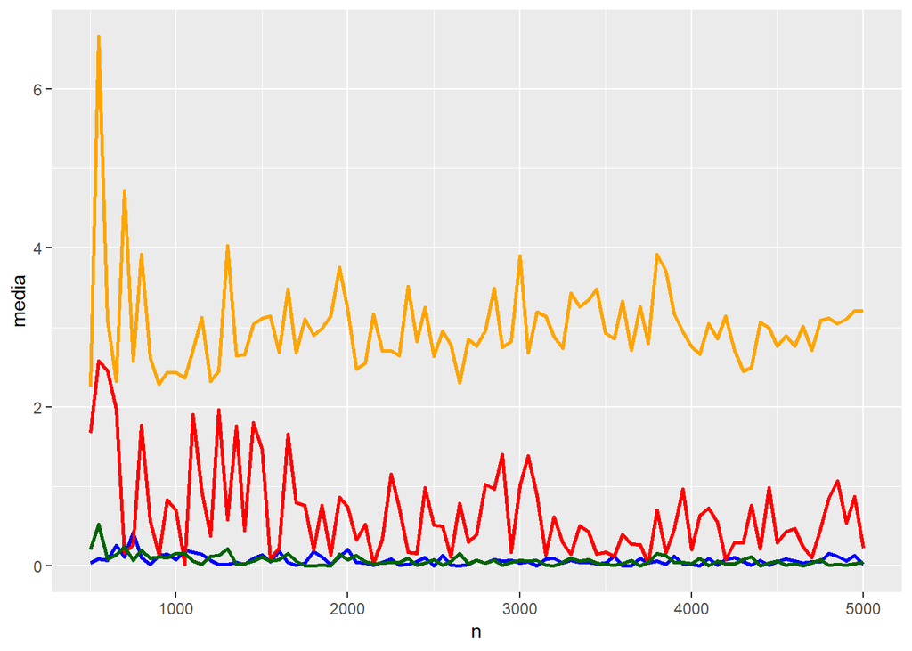

```r
dati.momenti <- tibble(n = n, media = abs(m-media), varianza = abs(v-varianza), skewness = abs(s-skewness), curtosi = abs(c-curtosi))
ggplot(data = dati.momenti) +
  geom_line(aes(x=n, y=media), color="blue", linewidth=1) +
  geom_line(aes(x=n, y=varianza), color="red", linewidth=1) +
  geom_line(aes(x=n, y=skewness), color="darkgreen", linewidth=1) +
  geom_line(aes(x=n, y=curtosi), color="orange", linewidth=1)
```

Si vede che tendono tutte a convergere al valore teorico, l’unico valore che non converge è la Curtosi, che si vede convergere ad un valore uguale alla $Curtosi_{teorica}+3$.

Informandomi ho trovato l’“Excess Kurtosis”, che sembra spiegare il motivo per questa differenza.

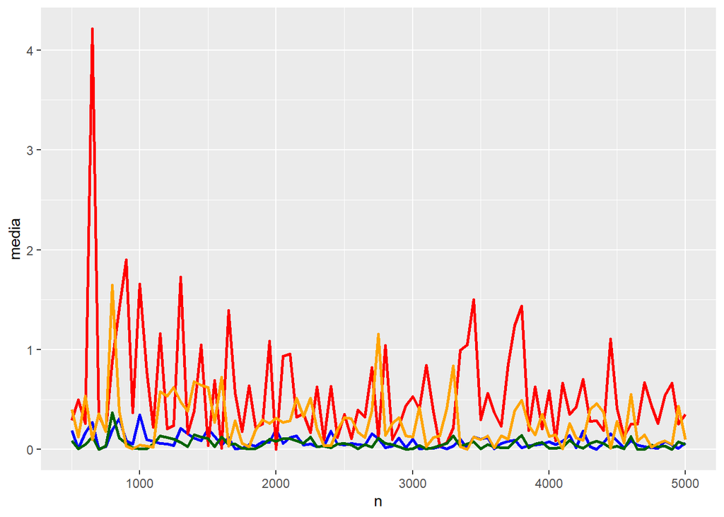

```r
numero.valori.generati.normale <- 10

media <- numero.valori.generati.normale
varianza <- 2*numero.valori.generati.normale
skewness <- sqrt(8/numero.valori.generati.normale)
curtosi <- 12/numero.valori.generati.normale

n <- vector()
m <- vector()
v <- vector()
s <- vector()
c <- vector()

for (numero.ripetizioni.montecarlo in seq(500, 5001, 50))
{
  distribuzione.T <- array(dim = numero.ripetizioni.montecarlo)
  for (i in 1:numero.ripetizioni.montecarlo)
  {
    valori.normale <- rnorm(numero.valori.generati.normale);
    distribuzione.T[i] <- sum(valori.normale**2)
  }

  m1 <- moment(distribuzione.T, order = 1, central = TRUE)
  m2 <- moment(distribuzione.T, order = 2, central = TRUE)
  m3 <- moment(distribuzione.T, order = 3, central = TRUE)
  m4 <- moment(distribuzione.T, order = 4, central = TRUE)

  media_montecarlo <- moment(distribuzione.T, order = 1, central = FALSE)
  varianza_montecarlo <- m2 - m1^2
  skewness_montecarlo <- m3/sqrt(m2^3)
  excess.curtosi_montecarlo <- m4/m2^2 -3

  n <- c(n, numero.ripetizioni.montecarlo)
  m <- c(m, media_montecarlo)
  v <- c(v, varianza_montecarlo)
  s <- c(s, skewness_montecarlo)
  c <- c(c, excess.curtosi_montecarlo)
}
dati.momenti <- tibble(n = n, media = abs(m-media), varianza = abs(v-varianza), skewness = abs(s-skewness), curtosi = abs(c-curtosi))
ggplot(data = dati.momenti) +
  geom_line(aes(x=n, y=media), color="blue", linewidth=1) +
  geom_line(aes(x=n, y=varianza), color="red", linewidth=1) +
  geom_line(aes(x=n, y=skewness), color="darkgreen", linewidth=1) +
  geom_line(aes(x=n, y=curtosi), color="orange", linewidth=1)
```

### 3.

Nell’ultimo punto possiamo vedere la distribuzione $T_n$ calcolata più volte incrementando $n$ prima a $4$, poi a $10$, $100$, $1000$ e $10000$.

Si vede chiaramente come la distribuzione normale $N(n, 2n)$ riesca sempre meglio a catturare l’andamento della distribuzione $T_n$.

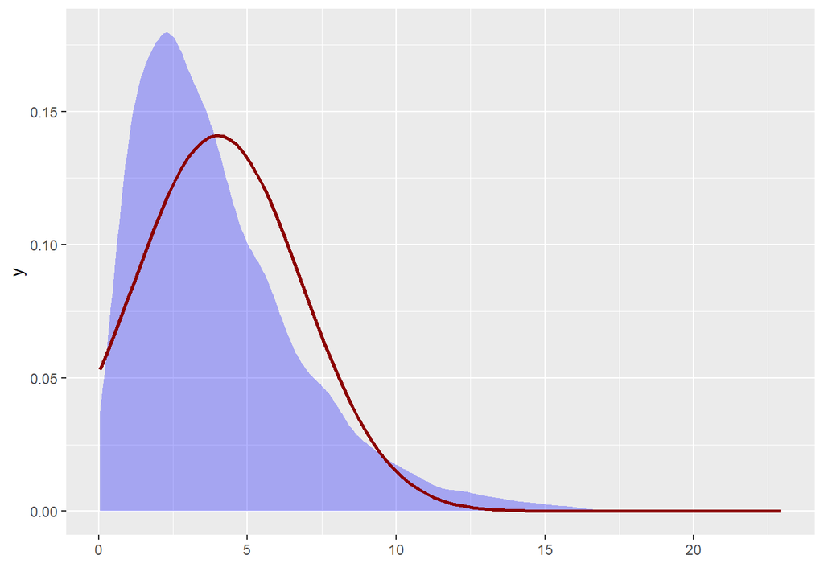

```r
numero.valori.generati.normale <- 4
numero.ripetizioni.montecarlo <- 5000

distribuzione.T <- array(dim = numero.ripetizioni.montecarlo)
for (i in 1:numero.ripetizioni.montecarlo)
{
  valori.normale <- rnorm(numero.valori.generati.normale);
  distribuzione.T[i] <- sum(valori.normale**2)
}

media <- numero.valori.generati.normale
varianza <- 2*numero.valori.generati.normale

ggplot(data=dati.teorici) +
  geom_density(aes(x=distribuzione.T), color="transparent", fill="blue", alpha=0.3) +
  stat_function(fun = dnorm, n = 101, args = list(mean = media, sd = sqrt(varianza)), color="darkred", linewidth=1) + xlab("")
```

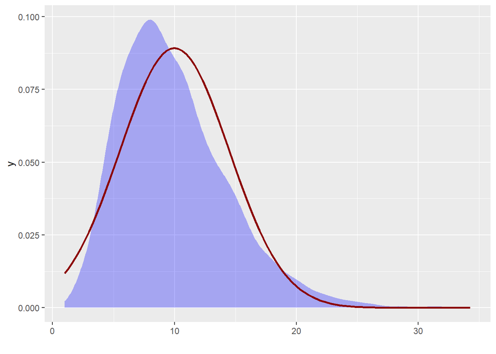

```r
numero.valori.generati.normale <- 10
numero.ripetizioni.montecarlo <- 5000

distribuzione.T <- array(dim = numero.ripetizioni.montecarlo)
for (i in 1:numero.ripetizioni.montecarlo)
{
  valori.normale <- rnorm(numero.valori.generati.normale);
  distribuzione.T[i] <- sum(valori.normale**2)
}

media <- numero.valori.generati.normale
varianza <- 2*numero.valori.generati.normale

ggplot(data=dati.teorici) +
  geom_density(aes(x=distribuzione.T), color="transparent", fill="blue", alpha=0.3) +
  stat_function(fun = dnorm, n = 101, args = list(mean = media, sd = sqrt(varianza)), color="darkred", linewidth=1) + xlab("")
```

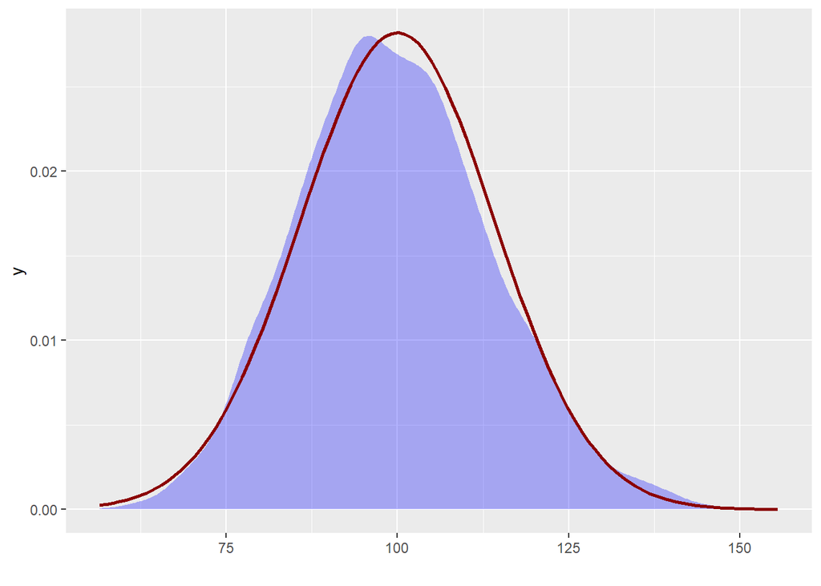

```r
numero.valori.generati.normale <- 100
numero.ripetizioni.montecarlo <- 5000

distribuzione.T <- array(dim = numero.ripetizioni.montecarlo)
for (i in 1:numero.ripetizioni.montecarlo)
{
  valori.normale <- rnorm(numero.valori.generati.normale);
  distribuzione.T[i] <- sum(valori.normale**2)
}

media <- numero.valori.generati.normale
varianza <- 2*numero.valori.generati.normale

ggplot(data=dati.teorici) +
  geom_density(aes(x=distribuzione.T), color="transparent", fill="blue", alpha=0.3) +
  stat_function(fun = dnorm, n = 101, args = list(mean = media, sd = sqrt(varianza)), color="darkred", linewidth=1) + xlab("")
```

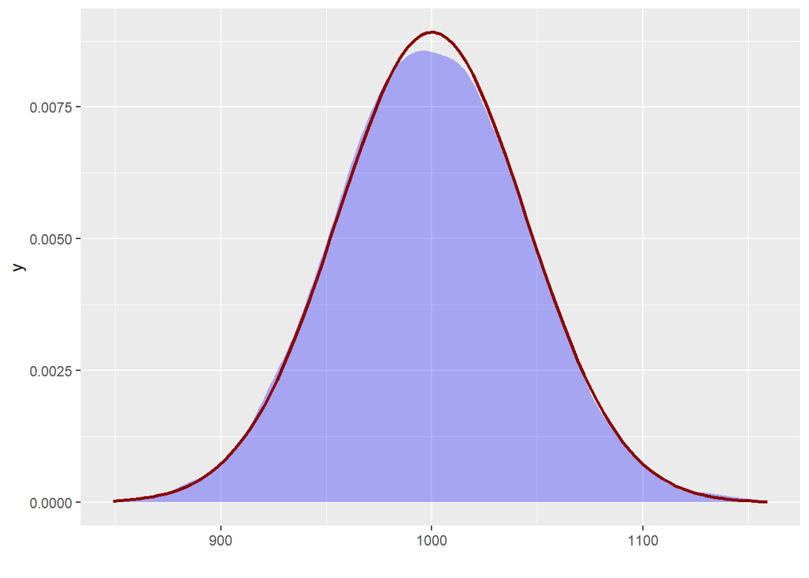

```r
numero.valori.generati.normale <- 1000
numero.ripetizioni.montecarlo <- 5000

distribuzione.T <- array(dim = numero.ripetizioni.montecarlo)
for (i in 1:numero.ripetizioni.montecarlo)
{
  valori.normale <- rnorm(numero.valori.generati.normale);
  distribuzione.T[i] <- sum(valori.normale**2)
}

media <- numero.valori.generati.normale
varianza <- 2*numero.valori.generati.normale

ggplot(data=dati.teorici) +
  geom_density(aes(x=distribuzione.T), color="transparent", fill="blue", alpha=0.3) +
  stat_function(fun = dnorm, n = 101, args = list(mean = media, sd = sqrt(varianza)), color="darkred", linewidth=1) + xlab("")
```

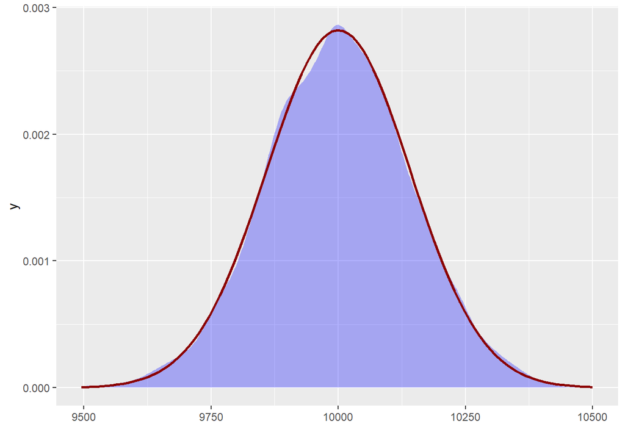

```r
numero.valori.generati.normale <- 10000
numero.ripetizioni.montecarlo <- 5000

distribuzione.T <- array(dim = numero.ripetizioni.montecarlo)
for (i in 1:numero.ripetizioni.montecarlo)
{
  valori.normale <- rnorm(numero.valori.generati.normale);
  distribuzione.T[i] <- sum(valori.normale**2)
}

media <- numero.valori.generati.normale
varianza <- 2*numero.valori.generati.normale

ggplot(data=dati.teorici) +
  geom_density(aes(x=distribuzione.T), color="transparent", fill="blue", alpha=0.3) +
  stat_function(fun = dnorm, n = 101, args = list(mean = media, sd = sqrt(varianza)), color="darkred", linewidth=1) + xlab("")
```